# Chapter 1: The Challenger Space Shuttle Disaster

Paul Northrop

2017-04-17

## Preliminaries

This vignette contains ideas and techniques that are not covered until later in STAT1004 and others (stochastic simulation and logistic regression) that are not part of the STAT1004 syllabus. Therefore, you should not worry too much about these details: just try to get a sense of how the R code works. The questions and comments below are there to prompt you to think about things.

For information about R see [STAT1006 Moodle page](https://moodle.ucl.ac.uk/course/view.php?id=7596) (if you are taking STAT1006) or [Introduction to R Moodle page](https://moodle.ucl.ac.uk/course/view.php?id=37877) (if you are not taking STAT1006, e.g. Natural Sciences students).

The R code used in this vignette are available here.

If you have any questions please ask them using the [STAT1004 discussion forum](https://moodle.ucl.ac.uk/mod/hsuforum/view.php?id=1410864).

## The Challenger Space Shuttle Disaster

In the first lecture of STAT1004 we discussed the Challenger Space Shuttle Disaster. In this vignette we are concerned mainly with the R code, so there is very little discussion of the problem, the data or statistical ideas. For discussion of these see the notes and/or lecture slides in the [Notes](https://moodle.ucl.ac.uk/course/view.php?id=3419&section=3) section of the STAT1004 Moodle page.

In this vignette we consider how R can be used to analyse data related to this disaster. See Dalal, Fowlkes, and Hoadley (1989) for more information about these data and analyses to estimate the probability of a catastrophic failure of the Challenger space shuttle under the launch conditions on 28th January 1986. This paper is used as a [worked example](https://moodle.ucl.ac.uk/mod/resource/view.php?id=2125123) for the [STAT1004 Meet your Professor ICA](https://moodle.ucl.ac.uk/course/view.php?id=3419&section=4).

In the following R commands follow the command prompt `>` and `#` is used to create a comment, that is, to prevent R from trying to execute text that contains comments rather than a command.

First we load the `stat1004` package.

```r
> library(stat1004)
```

### The data

The data are available in a **data frame** called `shuttle`. A data frame is what R calls a table of data.

```r
> # Print the data to the screen
> shuttle
   flight       date damaged temperature pressure
1       1 21/04/1981       0          66       50
2       2 12/11/1981       1          70       50
3       3 22/03/1982       0          69       50
4       4 11/11/1982       0          68       50
5       5 04/04/1983       0          67       50
6       6 18/06/1983       0          72       50
7       7 30/08/1983       0          73      100
8       8 28/11/1983       0          70      100
9       9 03/02/1984       1          57      200
10     10 06/04/1984       1          63      200
11     11 30/08/1984       1          70      200
12     12 05/10/1984       0          78      200
13     13 08/11/1984       0          67      200
14     14 24/01/1985       3          53      200
15     15 12/04/1985       0          67      200
16     16 29/04/1985       0          75      200
17     17 17/06/1985       0          70      200
18     18 29/07/1985       0          81      200
19     19 27/08/1985       0          76      200
20     20 03/10/1985       0          79      200
21     21 30/10/1985       2          75      200
22     22 26/11/1986       0          76      200
23     23 21/01/1986       1          58      200
24     24 28/01/1986      NA          31      200
```

1. **What do you think `NA` means?**

```r
> # The function head() prints only the first 6 lines of the data (useful to see the structure of large datasets)
> head(shuttle)
  flight       date damaged temperature pressure
1      1 21/04/1981       0          66       50
2      2 12/11/1981       1          70       50
3      3 22/03/1982       0          69       50
4      4 11/11/1982       0          68       50
5      5 04/04/1983       0          67       50
6      6 18/06/1983       0          72       50
```

2. **Can you guess which R function prints only the last 6 lines of the data?**

```r
> # Tabulate the number of O-rings with thermal distress
> table(shuttle[, "damaged"])

 0  1  2  3
16  5  1  1
```

```r
> # Repeat and assign the outut to the vector o_ring_table
> o_ring_table <- table(shuttle[, 3])
```

**Note the different way to get the column that we want.**

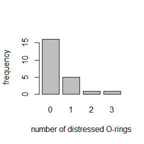

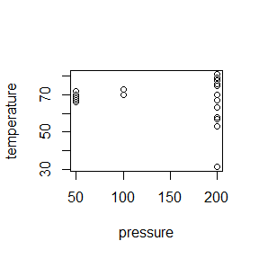

```r
> # A barplot of the numbers of distressed O-rings
> barplot(o_ring_table, xlab = "number of distressed O-rings", ylab = "frequency")
> attach(shuttle)
The following object is masked from package:datasets:

    pressure
> # A scatter plot of temperature against pressure
> plot(pressure, temperature)
```

3. **Can you see what `attach(shuttle)` enabled us to do? Type `?attach` to find out what the `attach()` function does.**

**Did you also note the warning message? This means that there exists another variable called `pressure`, in the R package called `datasets`. [Type `library(help = "datasets")` to see all the datasets available in the `datasets` package.] Using `attach(shuttle)` means that if we ask R for the variable `pressure` then R gives us `shuttle[, "pressure"]`. Otherwise `pressure` would give us the data in the `datasets` package. This highlights the fact that if we use `attach()` then we need to be careful.**

```r
> # The opposite of the function attach() is the function detach()
> detach(shuttle)
```

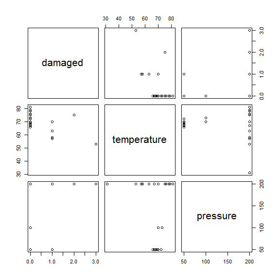

```r
> pairs(shuttle[, 3:5])
```

4. **Can you work out what the `3:5` bit is used for and what the `pairs()` function does?**

```r
> # Remove the zeros from the O-ring damage data
> not_zero <- shuttle$damaged > 0
> not_zero
 [1] FALSE  TRUE FALSE FALSE FALSE FALSE FALSE FALSE  TRUE  TRUE  TRUE
[12] FALSE FALSE  TRUE FALSE FALSE FALSE FALSE FALSE FALSE  TRUE FALSE
[23]  TRUE    NA
```

5. **Can you see what the vector `not_zero` contains?**

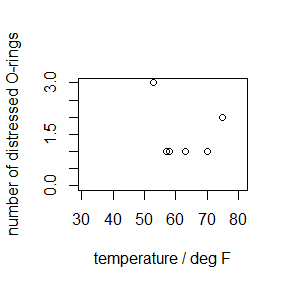

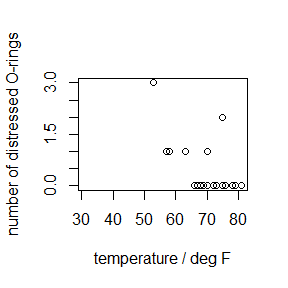

```r
> xlim <- range(shuttle$temperature)
> xlim
[1] 31 81
> # Plot with no zeros
> plot(shuttle$temperature[not_zero], shuttle$damaged[not_zero], xlim = xlim, ylim = c(0, 3), ann = FALSE)
> title(xlab = "temperature / deg F", ylab = "number of distressed O-rings")
> # Plot of all the data
> plot(shuttle$temperature, shuttle$damaged, ann = FALSE)
> title(xlab = "temperature / deg F", ylab = "number of distressed O-rings")
```

6. **Can you see/guess what the functions `range` and `title` and the function arguments `xlim`, `ann`, `xlab` and `ylab` do?**
7. **Did you see yet another way to refer to the variable `temperature` in the `shuttle` dataset?**

### Relating the probability of O-ring damage to temperature

This section involves a statistical model, a *logistic regression model*, that is not part of the STAT1004 syllabus, so don’t worry too much about the details that follow. However, this section involves things that we *will* study later in STAT1004, namely *independence*, the *binomial distribution* and (the general concept of) *regression*. We fit the model using a general fitting method called *maximum likelihood estimation*. This method is not formally part of the STAT1004 syllabus, but we will look at it very briefly later in the course.

Consider the six O-rings on the space shuttle. We suppose that on a launch conducted at temperature $t$ degrees F:

- each O-ring has a probability $p(t)$ of suffering thermal distress;
- whether or not a given O-ring suffers thermal distress is not affected by whether or not other O-rings suffer thermal distress, that is, the O-rings are independent of each other in this respect.

Under these assumptions the number of O-rings that suffer thermal distress has a binomial distribution with parameters $6$ and $p(t)$. We will study this distribution in Section 5.3 of the [STAT1004 notes](https://moodle.ucl.ac.uk/pluginfile.php/3054127/mod_resource/content/22/STAT1004notes-2x1.pdf). We have reason to believe that $p(t)$ depends on $t$, that is, the probability that an O-ring suffers thermal distress is different for different launch temperatures. A simple model that is used in this kind of situation is a *linear logistic regression model*, in which
$$\ln \left(\frac{p(t)}{1-p(t)}\right) = \alpha + \beta t,$$
for some unknown constants $\alpha$ and $\beta$. That is, the *logit* $\log[p(t) / (1-p(t))]$ of $p(t)$ is assumed to be a linear function of $t$. Inverting this equation gives
$$p(t) = \frac{e^{\alpha + \beta t}}{1 + e^{\alpha + \beta t}}.$$

8. **Why would it not make sense to suppose that $p(t)$ is a linear function of $t$? [Bear in mind that $p(t)$ is a probability and therefore can be no smaller than 0 and no larger than 1.]**
9. **How does $p(t)$ behave as $t$ becomes very small, and as $t$ becomes very large, and how does this depend on the value of $\beta$?**
10. **What happens in the special case where $\beta = 0$?**

A linear logistic regression model is a special case of a Generalized Linear Model. The function `glm()` can be used to fit this type of model, using *maximum likelihood estimation* to estimate the unknown parameters (or *coefficients*) $\alpha$ and $\beta$. First we create *response* data `y` (numbers of O-rings with and without thermal distress) and the *explanatory* data `x` (the launch temperatures).

```r
> # Create a matrix y containing 2 columns:
> #   column 1: number of O-rings WITH thermal distress
> #   column 2: number of O-rings WITHOUT thermal distress
> y <- cbind(shuttle[1:23, 3], 6 - shuttle[1:23, 3])
> head(y)
     [,1] [,2]
[1,]    0    6
[2,]    1    5
[3,]    0    6
[4,]    0    6
[5,]    0    6
[6,]    0    6
> x <- shuttle[1:23, 4]
> x
 [1] 66 70 69 68 67 72 73 70 57 63 70 78 67 53 67 75 70 81 76 79 75 76 58
```

Then we fit the model.

```r
> shuttle_fit <- glm(y ~ x, family = binomial)
> # Produce a summary of the estimates.  There is a lot of output: only look at the
> # numbers in the column headed "Estimate".
> summary(shuttle_fit)

Call:
glm(formula = y ~ x, family = binomial)

Deviance Residuals:
    Min       1Q   Median       3Q      Max
-0.9876  -0.7798  -0.4987  -0.2975   2.7483

Coefficients:
            Estimate Std. Error z value Pr(>|z|)
(Intercept)  6.75183    2.97989   2.266  0.02346 *
x           -0.13971    0.04647  -3.007  0.00264 **
---
Signif. codes:  0 '***' 0.001 '**' 0.01 '*' 0.05 '.' 0.1 ' ' 1

(Dispersion parameter for binomial family taken to be 1)

    Null deviance: 28.761  on 22  degrees of freedom
Residual deviance: 19.093  on 21  degrees of freedom
AIC: 36.757

Number of Fisher Scoring iterations: 5
> alpha_hat <- shuttle_fit$coefficients[1]
> beta_hat <- shuttle_fit$coefficients[2]
```

```r
> temp <- seq(from = 30, to = 85, by = 0.1)
> linear_predictor <- alpha_hat + beta_hat * temp
> fitted_curve <- exp(linear_predictor) / (1 + exp(linear_predictor))
```

11. **Can you gues what the function `seq` does? Use `?seq` to find out.**

We plot the *proportions* of distressed O-rings against temperature with the fitted logistic probability curve $p(t)$ superimposed. The second plot is the same as the plot in the lecture slides.

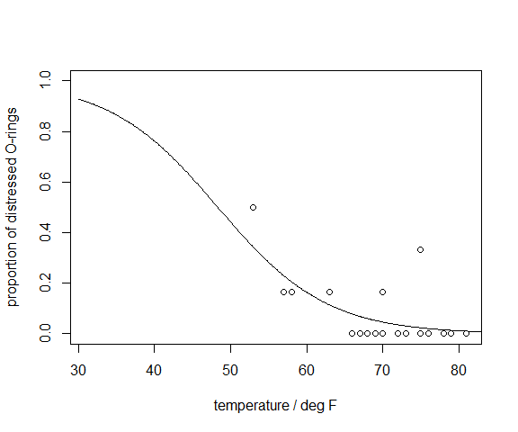

```r
> plot(shuttle$temperature, shuttle$damaged / 6, ann = FALSE, ylim = c(0, 1))
> title(xlab = "temperature / deg F", ylab = "proportion of distressed O-rings")
> lines(temp, fitted_curve)
```

Now we produce a better plot, one that is similar to the plot that appears in the lecture slides.

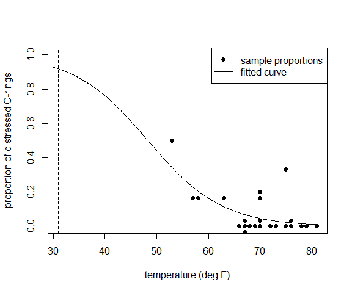

```r
> repeated_data <- which(duplicated(shuttle[, 3:4]))
> shuttle[repeated_data, ]
   flight       date damaged temperature pressure
11     11 30/08/1984       1          70      200
13     13 08/11/1984       0          67      200
15     15 12/04/1985       0          67      200
17     17 17/06/1985       0          70      200
22     22 26/11/1986       0          76      200
> new_damaged <- shuttle$damaged
> new_damaged[c(11, 13, 17, 22)] <- new_damaged[c(11, 13, 17, 22)] + 0.2
> new_damaged[15] <- new_damaged[15] - 0.2
> plot(shuttle$temperature, new_damaged / 6, ann = FALSE, ylim = c(0, 1), pch = 16)
> title(xlab = "temperature (deg F)", ylab = "proportion of distressed O-rings")
> lines(temp, fitted_curve)
> legend("topright", legend = c("sample proportions", "fitted curve"), pch=c(16, -1), lty = c(-1, 1))
> abline(v = 31, lty = 2)
```

12. **Can you see how the second plot is different from the first plot and identify the bits of the R code that do this? To find our about the many options for changing the appearance of a plot use `?par`.**